# Week 09 - Spatial data

- Show All Code
- Hide All Code

Introduction to Spatial Data

Welcome to out first session on **Spatial data analysis**! By the end of this session, you will:

```r
library(needs)
needs(osmdata,
      sf)
```

- Understand what spatial (geographic) data are and why we should consider spatial data in the social sciences
- Learn R’s `sf` package for storing and manipulating spatial vector data
- Load and inspect spatial data formats (e.g., *Shapefiles, GeoJSON*)
- Understand and apply coordinate reference systems (CRS) and projections
- Perform basic geometric operations on vector data
- Create basic spatial visualizations

# Spatial thinking in the Social Sciences

These last weeks we asked: Who is connected to whom, and how do these structures influence relationships and individual opinions, behavior and attitudes? Starting from this week, we ask ourselves: **Who is close to whom** - and what does this mean?

Spatial thinking is strongly based on the idea that:

> “Everything is related to everything else, but near things are more related than distant things.” (First law of geography - (Tobler 1970))

It thus refers to reasoning about **location**, **distance**, and **spatial relationships** and can for example be useful in answering questions such as:

- Are healthcare facilities equally accessible to all neighborhoods?
- Is crime concentrated in specific urban areas due to overlapping social conditions?
- Do voting patterns show spatial clustering due to shared environments?

# What is Spatial Data?

**Spatial data** is any data that has a geographical attribute. It contains information about the **location** and/or shape of physical features on earth and can include much more than just the coordinates on a standard dateset (Pebesma and Bivand 2023).

For example: A dataset on schools might contain school names, addresses, and exact coordinates (latitude/longitude) — allowing us to map them.

Spatial data is often **unstructured**:

- Formats vary (Shapefiles, GeoJSON, GPKG, KML)
- Coordinate systems may be missing or mismatched
- Boundaries and resolutions differ across datasets
- Files may contain only geometry but no relevant attributes

Thus data must be **cleaned, projected and joined** to be useful for further analysis.

## GIS

**Geographic Information systems** were originally developed in the 1960s-90s as a standalone software to manage spatial data. Today, spatial data tools are more and more integrated into data science languages like **R** and **Python** - bringing spatial data analysis into reproducible workflows.

[figure not shown]

Original map made by John Snow in 1854. Cholera cases are highlighted in black, showing the clusters of cholera cases (indicated by stacked rectangles) in the London epidemic of 1854. The map was created in order to better understand the pattern of cholera spread in the 1854 Broad Street cholera outbreak, which Snow would use as an example of how cholera spread via the fecal-oral route through water systems as opposed to the miasma theory of disease spread. The contaminated pump is located at the intersection of Broad Street and Cambridge Street (now Lexington Street), running into Little Windmill Street. The map marks an important part of the development of epidemiology as a field, and of disease mapping as a whole.(Snow 1855)

# Types of spatial data

In GIS, spatial data is typically represented in one of two formats (Moraga 2024).

**Raster data:**

Representation of geography as a continous of pixels (gridcells) with associated values. They normally represent **high resolution** features of the geograpy (like an image)

**Vector data:**

All geospatial vector data can be described by a set of geometric objects (so called simple features.)

The most common spatial types are **points**, **lines** and **polygons**:

| Geometric Entity | Description | R | Example |
| --- | --- | --- | --- |
| Points | Discrete locations in space defined by a single pair of coordinates. | `st_point(c(2, 3))` | Location of survey respondents, cities, bus stops |
| Lines | Ordered sequences of points connected by straight segments. | `st_linestring(rbind(c(1, 2), c(3, 4), c(5, 6)))` | Roads, rivers, subway lines |
| Polygons | Closed sequences of points defining areas; first and last points must be the same. | `st_polygon(list(rbind(c(1, 1), c(2, 4), c(5, 3), c(1, 1))))` | Country borders, administrative districts, lakes |

We can wrap one or more geometries to collections, allowing us to combine different objects and metadata:

| Function | Purpose |
| --- | --- |
| `st_point()` | Creates a single geometry (e.g., a point) |
| `st_sfc()` | Creates a vector (collection) of geometries |
| `st_sf()` | Creates a full spatial data frame (with data + geometry) |

[figure not shown]

Multipoint Geometry

[figure not shown]

Multiline Geometry

[figure not shown]

Multipolygo n Geometry

[figure not shown]

Geometry Collection

```r
point1 <- st_point(c(7.5, 1))
point2 <- st_point(c(4, pi))
point3 <- st_point(c(2, 2))

points_sfc <- st_sfc(point1, point2, point3)


points_sf <- st_sf(
  id = 1:3,
  label = c("A", "B", "C"),
  geometry = points_sfc
)


x_limits <- c(0, 12)
y_limits <- c(0, 12)


ggplot(data = points_sf) +
  geom_sf(color = "lavender", size = 4) +
  geom_sf_text(aes(label = label), nudge_y = 0.5, size = 2) +  # Adds labels above points
  coord_sf(xlim = x_limits, ylim = y_limits) +
  theme_minimal() +
  labs(x = "Longitude", y = "Latitude")




# Define the two lines as matrices
line1 <- st_linestring(matrix(c(6, 1,
                                2, 4,
                                6, 2), ncol = 2, byrow = TRUE))
line2 <- st_linestring(matrix(c(2, 5,
                                5, 4,
                                8, 5), ncol = 2, byrow = TRUE))

# Combine into an sfc with individual features
lines_sfc <- st_sfc(line1, line2)


lines_sf <- st_sf(
  label = c("Route A", "Route B"),
  geometry = lines_sfc
)


ggplot(data = lines_sf) +
  geom_sf(color = "purple", size = 6) +
  geom_sf_text(aes(label = label), size = 2, nudge_y = 0.5) +
  coord_sf(xlim = c(0, 10), ylim = c(0, 10)) +
  theme_minimal()



square1 <- st_polygon(list(matrix(c(1,8,
                                    4,1,
                                    3,4,
                                    7,3,
                                    1,8), ncol = 2, byrow = TRUE)))
square2 <- st_polygon(list(matrix(c(6,6,
                                    7,7,
                                    9,8,
                                    8,9,
                                    6,6), ncol = 2, byrow = TRUE)))

# Combine into sfc
polygons_sfc <- st_sfc(square1, square2)


polygons_sf <- st_sf(
  label = c("Area 1", "Area 2"),
  geometry = polygons_sfc
)


# Plot
ggplot(data = polygons_sf) +
  geom_sf(fill = "lavender", color = "navy") +
  geom_sf_text(aes(label = label), size = 4, nudge_y = 0.5) +
  coord_sf(xlim = c(0, 10), ylim = c(0, 10)) +
  theme_minimal()



ggplot() +
  # Polygons first (so they sit underneath)
  geom_sf(data = polygons_sf, fill = "lavender", color = "coral", size = 0.8) +
  geom_sf(data = lines_sf, color = "lightblue", size = 3, lineend = "round") +
  geom_sf(data = points_sf, color = "pink", size = 5) +
  theme_minimal()
```

While vector formats are great for discrete features, raster format can be more useful for the representation of continuous variables.

**Vector data formats**

- **Shapefile (.shp)**: legacy format, often comes with `.dbf`, `.shx`, etc.
- **GeoJSON (.json)**: used in web mapping, lightweight, human-readable.
- **Geopackage (.gpkg)**: modern format; compact, supports multiple layers in one file.
- **KML/KMZ**: used by Google Earth.

**Raster data formats**

- **TIFF (.tif)**: supports georeferencing and multi-band data; widely used.
- **NetCDF (.nc)**: used in climate science and geosciences.
- **Other image files** — JPEG, PNG (used rarely in analysis but common for display)

If needed we can also transform vector data to raster data and vice versa.

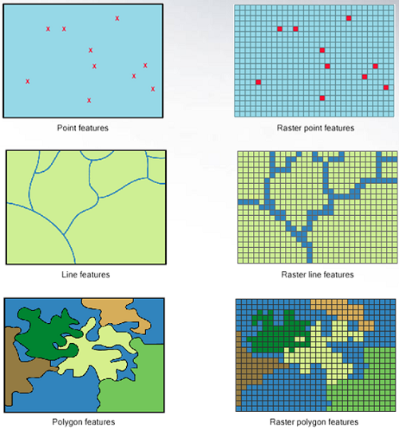

https://gsp.humboldt.edu/olm/Lessons/GIS/08%20Rasters/RasterToVector.html

For this lecture (and usually when using spatial data for the social sciences) we will focus on vector representation of data.

# Coordinate Reference Systems

Spatial data is data characterized by coordinates in a coordinate system. Different coordinate systems can be used for this, and the most important difference is whether coordinates are defined over a 2 dimensional or 3 dimensional space referenced to orthogonal axes (Cartesian coordinates), or using distance and directions (polar coordinates, spherical and ellipsoidal coordinates).

A **Coordinate Reference System** is a framework used to uniquely define spatial positions on Earth. It acts as the interface between the coordinares of a geographic object and its real-world location.

A CRS consists of two main concepts:

- **Coordinate system**: A set of mathematical rules that specify how coordinates are assigned to points
- **Datum**: Parameters that define the origin, scale and orientation of the coordinate system.
  - a **geodetic datum** is a datum that describes the relationship of a two- or three-dimensional coordinate system to the Earth

We use different Datums, because the earths shape is irregular. The *geoid* — the surface of constant gravitational potential approximating mean sea level — is not a perfect sphere or ellipsoid. To approximate the geoid, ellipsoids of revolution (ellipsoids with two identical minor axes) are used.

Fitting an ellipsoid to the Earth’s surface results in a datum. Different datums arise because ellipsoids can be fit globally *(e.g.: WGS84 (World Geodetic System 1984)*, used worldwide by GPS.) or locally (g.e.: *ETRS89 (European Terrestrial Reference System 1989)*, fixed to the European tectonic plate), resulting in varying levels of accuracy for different regions.

A **projection** converts geographical coordingates (longitude, lattitude) into planar cartesian coordinates (X,Y). Since it is impossible to provide an exact representation of a curved surface on a plane, specialized projections were developed for different regions of the world and different analytical applications.

For example, the images below show how identical circular areas appear at different points of the Earth under a Mercator projection (which preserves shapes), a Lambert equal-area projection (which preserves areas) and a Mollweide projection (preserving area proportions but distorting shape).

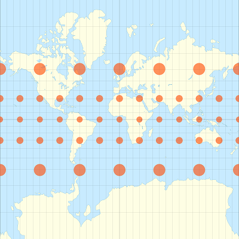

*Mercator projection: preserves angles, distorts size near poles*

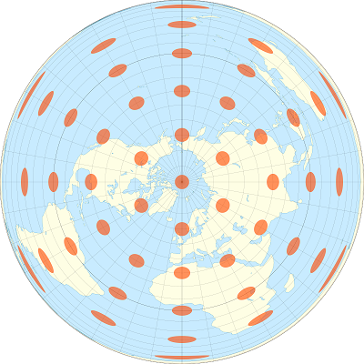

*Lambert projection: area-preserving, useful for mid-latitudes*

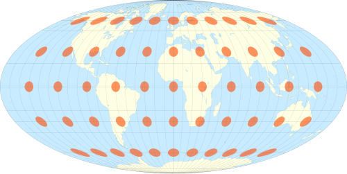

You can find a list of (in R) implemented projections using `sf::sf_proj_info(type = "proj")`.

Most tools for spatial analysis (including R-spatial packages) use PROJ, an open source C++ library that transforms coordinates from one CRS to another. They can be described in many ways including formalized “proj4 strings” such as `+proj=longlat` or identifying authority codes like EPSG-codes. The latter is more modern and the corresponding codes can be found on [this website](https://epsg.io/)

# The `sf package`

A **feature** is thought of as a thing, or an object in the real world, such as a building or a tree. As is the case with objects, they often consist of other objects. This is the case with features too: a set of features can form a single feature. A forest stand can be a feature, a forest can be a feature, a city can be a feature. A satellite image pixel can be a feature, a complete image can be a feature too.

Features have a *geometry* describing where on Earth the feature is located, and they have *attributes*, which describe other properties. The geometry of a tree can be the delineation of its crown, of its stem, or the point indicating its centre. Other properties may include its height, color, diameter at breast height at a particular date, and so on.

https://cran.r-project.org/web/packages/sf/index.html is the state of the art package for working with spatial vector data in R. It replaces older packages (that are still available like `sp`and `rgdal`) with a clean, modern interface that *aligns with the tidyverse* (Pebesma n.d.).

Every spatial object in `sf` contains:

1. Geometry (shapes/coordinates)
2. Coordinate Reference System (CRS/projection)
3. Attributes (data about the object)

The most common geometry types supported by the `sf` package are:

| Type | Description |
| --- | --- |
| `POINT` | Zero-dimensional geometry containing a single coordinate (e.g., a tree) |
| `LINESTRING` | One-dimensional sequence of points forming a path (e.g., a road or river) |
| `POLYGON` | Two-dimensional area enclosed by lines (e.g., a building footprint) |
| `MULTIPOINT` | Set of points (e.g., tree locations in a park) |
| `MULTILINESTRING` | Set of lines (e.g., transit routes in a city) |
| `MULTIPOLYGON` | Set of polygons (e.g., a country with multiple islands) |
| `GEOMETRYCOLLECTION` | Mixed set of geometry types (e.g., points, lines, polygons combined) |

We can also define empty geometries (placeholders) for spatial objects. It is similar to having an `NA` in a column of a data frame. This is useful to preserve data structure consistency, even if some lack location. We can check `st_is_empty()` to filter or check for empty geometries before performing operations.

```r
# Load Leipzig Polygon (with Stadtviertel) from Shapefile
leipzig <- sf::st_read(dsn = "Data/Leipzig/ot.shp") # dsn = Data Set Name,

leipzig
```

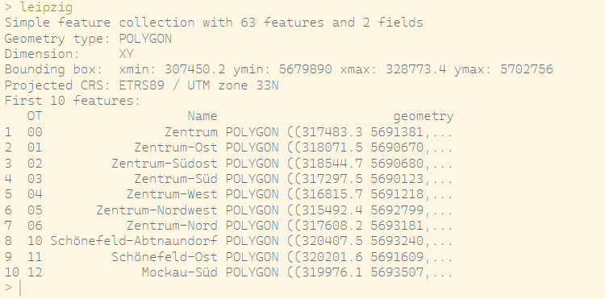

Sf-Objects in R

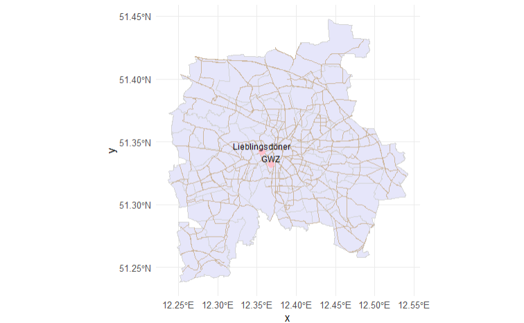

Lieblingsdöner und GWZ

```r
bb <- st_bbox(leipzig)

#streets <- opq(bbox = bb) |>
  #add_osm_feature(key = "highway") |>
  #osmdata_sf()

# Load streets (from OSM)
leipzig_streets <- streets$osm_lines |>
  filter(highway %in% c("motorway", "primary", "secondary", "tertiary")) |>  # filter larger streets only! Speed
  st_transform(4326) |>
  st_intersection(st_union(leipzig))


doeni <- st_sf(
  name = "Lieblingsdöner",
  geometry = st_sfc(st_point(c(12.3563, 51.3419)),
                    crs = 4326)
)


gwz <- st_sf(
  name = "GWZ",
  geometry = st_sfc(st_point(c(12.36845,51.3319)),
                    crs = 4326)
)

# Shapefile ins gleiche CRS transformieren
leipzig <- st_transform(leipzig,
                        4326)

# Plot everything
ggplot() +
  geom_sf(data = leipzig, fill = "lavender", color = "lightgray") +
  geom_sf(data = leipzig_streets, color = "bisque3", size = 0.3) +
  geom_sf(data = doeni, color = "pink", size = 3) +
  geom_sf_text(data = doeni, aes(label = name), nudge_y = 0.005, size = 3) +
  geom_sf(data = gwz, color = "pink", size = 3) +
  geom_sf_text(data = gwz, aes(label = name), nudge_y = 0.005, size = 3) +
  theme_minimal()
```

## Geometry creation

We can define strings, lines or polygons like above, using `st_point()`, `st_linestring()` or `st_polygon()`.

[figure not shown]

```r
line <- st_sf(
  name = "Connection",
  geometry = st_sfc(
    st_linestring(rbind(
      st_coordinates(doeni),
      st_coordinates(gwz)
    )),
    crs = 4326
  )
)

# Plot everything
ggplot() +
  geom_sf(data = leipzig, fill = "lavender", color = "lightgray") +
  geom_sf(data = leipzig_streets, color = "bisque3", size = 0.3) +
  geom_sf(data = doeni, color = "pink", size = 3) +
  geom_sf_text(data = doeni, aes(label = name), nudge_y = 0.005, size = 3) +
  geom_sf(data = gwz, color = "pink", size = 3) +
  geom_sf_text(data = gwz, aes(label = name), nudge_y = 0.005, size = 3) +
  geom_sf(data = line, color = "lightblue", size = 1) +
  theme_minimal()
```

## Geometric confirmation

```r
# Check if geometries are valid - meaning following the formal rules
st_is_valid(leipzig_streets)

# Check geometry type
st_geometry_type(leipzig_streets)

# Check if geometry is empty
st_is_empty(doeni)

# Get CRS
st_crs(leipzig)
st_crs(doeni)

# Ceck if point lies inside polygon
st_contains(leipzig, doeni)
```

## Geometric operations

```r
# Buffer: create a buffer zone around a point (e.g., 500 meters)
doeni_buffer <- st_buffer(doeni, dist = 500, 4326)  # approx 500m in degrees (~very rough!)


# Intersection: streets intersecting with the buffer
streets_near_doeni <- st_intersection(leipzig_streets, doeni_buffer) |>
  select(osm_id, name, geometry)



# Difference: parts of streets outside buffer
streets_outside <- st_difference(leipzig_streets, doeni_buffer) |>
  select(osm_id, name, geometry)
```

We can check all methods for `sf`- objects with `methods(class = "sf")`

## Add data to simple features

Even though these plots already look pretty cool, we as sociologists are usually interested not just in looking at the placement of objects, but more on how these relate to further variables. The `sf` handles data like a data.frame, allowing us to combine it (and add) further data to the frames and thus analyzing the relations between different phenomena.

Imagine if we were interested in analyzing whether the movement of actors in Leipzig is dependent on my Lieblingsdöner. For a descriptive (and visual analysis) we load, clean and add data on the innercity movements of Leipzig.

```r
zuzuege_innerstaedtisch_2024 <- read_csv("Data/Leipzig/Bevölkerungsbewegung_Wanderungen.csv") |>
  filter(Sachmerkmal == "Innerstädtische Zuzüge") |>
  pivot_longer(
    cols = 3:12,              # Spalten 2015–2024
    names_to = "Jahr",
    values_to = "Zuzuege"
  ) |>
  filter(Jahr == "2024") |> # Nur Jahr 2024
  mutate(Zuzuege = as.numeric(Zuzuege))



leipzig_data <- left_join(x = shape,                  # Zusammenfügen der Daten über den Ortsteil (Name / Gebiet)
                          y = zuzuege_innerstaedtisch_2024,
                          by = c("Name" = "Gebiet"))
```

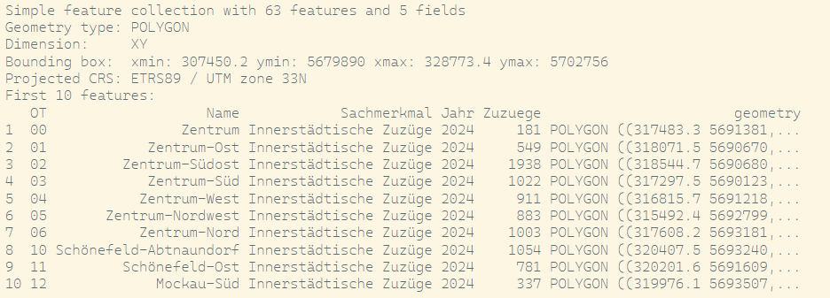

Leipzig sf with Information on Innerstädtische Zuzüge

And if we plot this now with my favorite Döner:

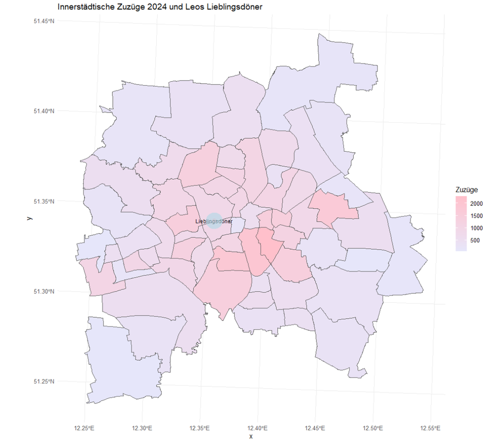

Innerstädtische Zuzüge

```r
ggplot(leipzig_data) +
  geom_sf(aes(fill = Zuzuege)) +
  scale_fill_gradient(low = "lavender", high = "pink", na.value = "grey90") +
  geom_sf(data = doeni, color = "pink", size = 3) +
  geom_sf_text(data = doeni, aes(label = name), nudge_y = 0.005, size = 3) +
  # Buffer around the Döner location
  geom_sf(data = doeni_buffer, fill = "lightblue", color = NA, alpha = 0.6) +
  theme_minimal() +
  labs(title = "Innerstädtische Zuzüge 2024 und Leos Lieblingsdöner", fill = "Zuzüge")
```

we can obviously see, that people in Leipzig are motivated to move as close to my favorite Döner as possible 😉

Lets try this for ourselves:

You can download a GeoJson with Information on the boundaries of world countries, their name, ISO Code, Affiliated countries from [here](https://hub.arcgis.com/datasets/esri::world-countries-generalized/explore)

1. Load the world boundaries as an `sf` object using `st_read()`.
2. Plot the countries using different Coordinate Reference Systems (CRSs). Observe how these different CRSs change the appearance of the world.

From [here](https://simplemaps.com/data/countries) you can download the free version of the simplemaps information metadata on the world countries. It contains information on different countries population and economic information.

1. Add the information from the .csv to your `sf`-object.
2. Find the five countries with the highest and lowest median age.
3. Visualize median age using a color gradient.
4. Identify which countries drive on the left.
5. Visualize the driving side on a map.

## References

Moraga, Paula. 2024. *Spatial Statistics for Data Science: Theory and Practice with R*. First edition. Chapman & Hall/CRC Data Science Series. Boca Raton: CRC Press, Taylor & Francis Group.

Pebesma, Edzer. n.d. “Simple Features for R.” https://r-spatial.github.io/sf/articles/sf1.html. Accessed May 27, 2025.

Pebesma, Edzer, and Roger Bivand. 2023. *Spatial Data Science: With Applications in R*. 1st ed. New York: Chapman and Hall/CRC. https://doi.org/10.1201/9780429459016.

Snow, John. 1855. *On the Mode of Communication of Cholera*. London : John Churchill.

Tobler, W. R. 1970. “A Computer Movie Simulating Urban Growth in the Detroit Region.” *Economic Geography* 46: 234–40. https://doi.org/10.2307/143141.

## Copyright

© 2026 Leonie Steinbrinker